# Inferência: testes de permutação e p-valores

Nazareno Andrade

# Intro

Técnicas de Reamostragem = {Bootstrap, Permutação, (jacknifing), …}

Disclaimer: em princípio tudo pode ser feito através de ICs, porém você verá e ouvirá falar muito de p-valores e testes como t-test, mann-withney, wilcoxon e Chi-squared. Então falaremos deles também.

## Os dados

```r
ratings_raw <- read_csv("dados/ml-latest-small/ratings.csv", col_types = "ccdi")
movies <- read_csv("dados/ml-latest-small/movies.csv", col_types = "ccc")
ratings = full_join(ratings_raw, movies, by = "movieId")
glimpse(ratings)
```

```
Observations: 105,343
Variables: 6
$ userId    <chr> "1", "1", "1", "1", "1", "1", "1", "1", "1", "1", "1", "1", "1...
$ movieId   <chr> "16", "24", "32", "47", "50", "110", "150", "161", "165", "204...
$ rating    <dbl> 4.0, 1.5, 4.0, 4.0, 4.0, 4.0, 3.0, 4.0, 3.0, 0.5, 4.0, 0.5, 4....
$ timestamp <int> 1217897793, 1217895807, 1217896246, 1217896556, 1217896523, 12...
$ title     <chr> "Casino (1995)", "Powder (1995)", "Twelve Monkeys (a.k.a. 12 M...
$ genres    <chr> "Crime|Drama", "Drama|Sci-Fi", "Mystery|Sci-Fi|Thriller", "Mys...
```

Focaremos em alguns episódios de Star Wars

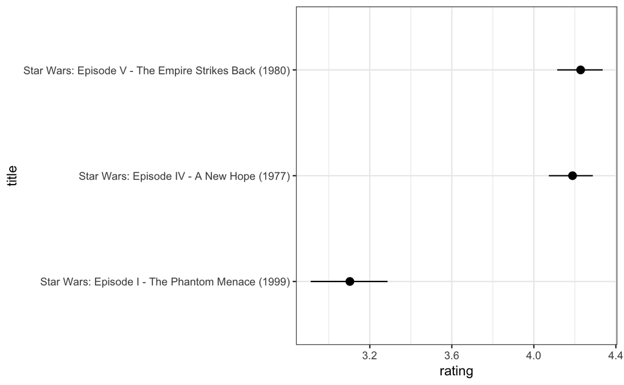

```r
sw = ratings %>% filter(grepl("Star Wars", title) &
                          (grepl("Episode IV -", title) |
                             grepl("Episode I -", title) |
                             grepl("Episode V -", title)))
ggplot(sw, aes(y = rating, x = title)) +
  stat_summary(fun.data = "mean_cl_boot") +
  coord_flip()
```

```r
nomes_episodios = c("Star Wars: Episode I - The Phantom Menace (1999)",
                    "", # não usamos
                    "", # não usamos
                    "Star Wars: Episode IV - A New Hope (1977)",
                    "Star Wars: Episode V - The Empire Strikes Back (1980)")

sw1x4 = sw %>%
  filter(title %in% c(nomes_episodios[1],
                      nomes_episodios[4])) %>%
  select(title, rating)
sw4x5 = sw %>%
  filter(title %in% c(nomes_episodios[4],
                      nomes_episodios[5])) %>%
  select(title, rating)
```

# Nosso framework

## Modo manual

```r
medias1x4 = sw1x4 %>%
  group_by(title) %>%
  summarise(media = mean(rating))
medias1x4
```

| title | media |
| --- | --- |
| Star Wars: Episode I - The Phantom Menace (1999) | 3.102941 |
| Star Wars: Episode IV - A New Hope (1977) | 4.188645 |

```r
medias4x5 = sw4x5 %>%
  group_by(title) %>%
  summarise(media = mean(rating))
medias4x5
```

| title | media |
| --- | --- |
| Star Wars: Episode IV - A New Hope (1977) | 4.188645 |
| Star Wars: Episode V - The Empire Strikes Back (1980) | 4.228070 |

```r
diff.media.observada.1x4 = diff(medias1x4$media)
diff.media.observada.4x5 = diff(medias4x5$media)
sprintf("Diferença observada nas amostras entre ep 1 e 4: %s", diff.media.observada.1x4)
```

```
[1] "Diferença observada nas amostras entre ep 1 e 4: 1.0857035121741"
```

```r
sprintf("Diferença observada nas amostras entre ep 4 e 5: %s", diff.media.observada.4x5)
```

```
[1] "Diferença observada nas amostras entre ep 4 e 5: 0.0394254867939079"
```

Episódio 1 x 4

```r
sum(abs(diffs) > abs(diff.media.observada.1x4)) / length(diffs)
```

```
[1] 0
```

Episódio 4 x 5

```r
# Testamos com > porque a diferença encontrada foi positiva!
sum(abs(diffs) > abs(diff.media.observada.4x5)) / length(diffs)
```

```
[1] 0.603
```

## Pacote resample

```r
library(resample)
permutationTest2(sw1x4,
                 mean(rating),
                 treatment = title)
```

```
Call:
permutationTest2(data = sw1x4, statistic = mean(rating), treatment = title)
Replications: 9999
Two samples, sample sizes are 136 273

Summary Statistics for the difference between samples 1 and 2:
                                                                                                          Observed
mean(rating): Star Wars: Episode I - The Phantom Menace (1999)-Star Wars: Episode IV - A New Hope (1977) -1.085704
                                                                                                                  Mean
mean(rating): Star Wars: Episode I - The Phantom Menace (1999)-Star Wars: Episode IV - A New Hope (1977) -0.0006545782
                                                                                                         Alternative
mean(rating): Star Wars: Episode I - The Phantom Menace (1999)-Star Wars: Episode IV - A New Hope (1977)   two.sided
                                                                                                         PValue
mean(rating): Star Wars: Episode I - The Phantom Menace (1999)-Star Wars: Episode IV - A New Hope (1977)  2e-04
```

```r
permutationTest2(sw4x5, mean(rating), treatment = title)
```

```
Call:
permutationTest2(data = sw4x5, statistic = mean(rating), treatment = title)
Replications: 9999
Two samples, sample sizes are 273 228

Summary Statistics for the difference between samples 1 and 2:
                                                                                                                 Observed
mean(rating): Star Wars: Episode IV - A New Hope (1977)-Star Wars: Episode V - The Empire Strikes Back (1980) -0.03942549
                                                                                                                       Mean
mean(rating): Star Wars: Episode IV - A New Hope (1977)-Star Wars: Episode V - The Empire Strikes Back (1980) -0.0004956178
                                                                                                              Alternative
mean(rating): Star Wars: Episode IV - A New Hope (1977)-Star Wars: Episode V - The Empire Strikes Back (1980)   two.sided
                                                                                                              PValue
mean(rating): Star Wars: Episode IV - A New Hope (1977)-Star Wars: Episode V - The Empire Strikes Back (1980) 0.4766
```

```r
permutationTest2(sw1x4, median(rating), treatment = title)
```

```
Call:
permutationTest2(data = sw1x4, statistic = median(rating), treatment = title)
Replications: 9999
Two samples, sample sizes are 136 273

Summary Statistics for the difference between samples 1 and 2:
                                                                                                           Observed
median(rating): Star Wars: Episode I - The Phantom Menace (1999)-Star Wars: Episode IV - A New Hope (1977)       -1
                                                                                                                  Mean
median(rating): Star Wars: Episode I - The Phantom Menace (1999)-Star Wars: Episode IV - A New Hope (1977) -5.0005e-05
                                                                                                           Alternative
median(rating): Star Wars: Episode I - The Phantom Menace (1999)-Star Wars: Episode IV - A New Hope (1977)   two.sided
                                                                                                           PValue
median(rating): Star Wars: Episode I - The Phantom Menace (1999)-Star Wars: Episode IV - A New Hope (1977)  2e-04
```

```r
permutationTest2(sw4x5, median(rating), treatment = title)
```

```
Call:
permutationTest2(data = sw4x5, statistic = median(rating), treatment = title)
Replications: 9999
Two samples, sample sizes are 273 228

Summary Statistics for the difference between samples 1 and 2:
                                                                                                                Observed
median(rating): Star Wars: Episode IV - A New Hope (1977)-Star Wars: Episode V - The Empire Strikes Back (1980)        0
                                                                                                                        Mean
median(rating): Star Wars: Episode IV - A New Hope (1977)-Star Wars: Episode V - The Empire Strikes Back (1980) -0.007450745
                                                                                                                Alternative
median(rating): Star Wars: Episode IV - A New Hope (1977)-Star Wars: Episode V - The Empire Strikes Back (1980)   two.sided
                                                                                                                PValue
median(rating): Star Wars: Episode IV - A New Hope (1977)-Star Wars: Episode V - The Empire Strikes Back (1980)      1
```

## Pacote coin

Teste da média

```r
library(coin)
oneway_test(rating ~ as.factor(title),
            data = sw4x5,
            distribution = "exact")

oneway_test(rating ~ as.factor(title),
            data = sw4x5,
            distribution = "exact") %>%
  pvalue()

pt = permutationTest2(sw4x5, mean(rating), treatment = title)
pt$stats$PValue
```

[output not shown]

Teste de que a mediana das populações de onde vieram as avaliações dos episódios são diferentes:

```r
median_test(rating ~ as.factor(title),
            data = sw4x5,
            distribution = "exact")

permutationTest2(sw4x5, median(rating), treatment = title)$stats %>% t()
```

[output not shown]

## Por que two-tailed

Normalmente estamos interessados em rejeitar a hipótese nula da igualdade. A igualdade está em torno do zero, e portanto a rejeição acontece quando o valor observado está longe de zero em qualquer direção. Existem testes one-tailed que não dão informação sobre se há diferença nas duras direções. Porém na prática é uma prática requerida que você decida o teste antes de realizá-lo, e é difícil decidir que apenas diferenças em uma direção serão relevantes. Além disso, devido à pressão por resultado, decidir usar one-tailed é sempre um truque que aumenta sua chance de produzir um teste com diferença significativa, o que é claramente uma manipulação na sua metodologia.

# Testes conhecidos que você pode encontrar

# Mann-withney-wilcoxon

Testa se a soma dos ranks das duas amostras são significativamente diferentes.

```r
library("coin")
wilcox_test(rating ~ as.factor(title),
            data = sw4x5,
            distribution = "exact") # tirando este parâmetro, usamos fórmula fechada em lugar de permutação
```

[output not shown]

## Chi-squared para associação entre duas variávies categóricas

Quando os resíduos do teste chi-quadrado para a associação entre duas categorias for maior que 3.84, rejeitamos a hipótese nula (de não associação) com p < .05.

```r
CrossTable(titanic$Survived,
           titanic$Pclass,
           prop.t = F,
           resid = TRUE)
```

```
   Cell Contents
|-------------------------|
|                       N |
| Chi-square contribution |
|           N / Row Total |
|           N / Col Total |
|-------------------------|


Total Observations in Table:  891


                 | titanic$Pclass
titanic$Survived |         1 |         2 |         3 | Row Total |
-----------------|-----------|-----------|-----------|-----------|
               0 |        80 |        97 |       372 |       549 |
                 |    21.178 |     2.365 |    15.950 |           |
                 |     0.146 |     0.177 |     0.678 |     0.616 |
                 |     0.370 |     0.527 |     0.758 |           |
-----------------|-----------|-----------|-----------|-----------|
               1 |       136 |        87 |       119 |       342 |
                 |    33.997 |     3.796 |    25.603 |           |
                 |     0.398 |     0.254 |     0.348 |     0.384 |
                 |     0.630 |     0.473 |     0.242 |           |
-----------------|-----------|-----------|-----------|-----------|
    Column Total |       216 |       184 |       491 |       891 |
                 |     0.242 |     0.207 |     0.551 |           |
-----------------|-----------|-----------|-----------|-----------|
```

Outro

```r
mosaic(survival ~ sex, data = titanic2, shade = T, legend = TRUE)
```

[output not shown]